# Specific Analysis

Laura Plutowski and Franziska Heinkele

26 Juni 2019

Load data:

```r
library(readr)
  Untreated = readRDS(paste0(wd,"/data/NCI_TPW_gep_untreated.rds"))
  Treated = readRDS(paste0(wd,"/data/NCI_TPW_gep_treated.rds"))
  Metadata = read_tsv(paste0(wd,"/data/NCI_TPW_metadata.tsv"))
  Drug_annotation = read.table(paste0(wd,"/data/drug_annotation.tsv"),
                               header = TRUE, sep ="\t", stringsAsFactors = TRUE)
```

# SPECIFIC ANALYSIS

From now on, we decided to focus our analysis on Vorinostat.

```r
Drug_annotation$Mechanism[grep(Drug_annotation$Drug, pattern= "vorinostat")]
```

```
## [1] HDAC inhibitor
## 12 Levels: DNA alkyltransferase inhibitor ...
```

The annotation data include information about vorinostats working mechanism as a **HDAC inhibitor** (HDAC = histone deacetylases). Normally, cells maintain a dynamic balance between acetylated and deacetylated histones.

- **Acetylated form**: Histones loose their positive charge when they are acetylated, what means that the negatively charged DNA is less bound to the histone proteins and the genes are more accessible. This form is promoted by the HDAC-Inhibitors, including vorinostat.
- **Deacetylated form**: Histones have a positive charge which causes a strong DNA binding. Genes can be hardly transcribed, including tumor-suppressorgenes. This form is promoted by the HDACs.

Vorinostats application as an anti-cancer medicine might origin from a better access to tumor-suppressorgenes in the acetylated form.

```r
target=Drug_annotation$target[grep(Drug_annotation$Drug, pattern= "vorinostat")]
```

[output not shown]

We see, that the targets of vorinostat are exclusively HDACs. In further analyses, we want to check their gene expression change under vorinostat- treatment since we can imagine that an increased inhibition might result in a higher production of HDACs to maintain the balance.

```r
Drug_annotation$indication[grep(Drug_annotation$Drug, pattern= "vorinostat")]
```

```
## [1] cutaneous T-cell lymphoma (CTCL)
## 15 Levels:  ...
```

Until now, the T-cell lymphoma is the only cancer-type which indicates vorinostat-ingestion.

# Table of content

1. General visualizations

- 1.1. Pie chart of tissue types
- 1.2.Density plot of general gene expression

2. Creation of Vorinostat-FC-matrix

3. Finding biomarkers

- 3.1. Biomarkers received from two-sided T-test
- 3.2. Biomarkers received from variance
- 3.3. Biomarkers received from FC values
  - 3.3.1. General Biomarkers
  - 3.3.2. Up and Downregulation of biomarkers
- 3.4. Comparison of the differently received biomarkers

4. Visualizations of biomarkers

- 4.1. Density plot of biomarker gene expression
- 4.2. Barplots of up- and downregulation of biomarkers
- 4.3. Visualization of biomarkers with Vulcanoplot

5.Are the targets for vorinostat (HDACs) part of our biomarkers?

6.Find biomarkers only for leukemia-celllines

## 1. General visualizations

### 1.1. Pie chart of tissue types

Which tissue types are we dealing with when we work with the vorinostat-treated celllines? To get an overview of this, we use tissue information from Metadata and add it to the Treated-matrix, then we select those columns which belong to Vorinostat treatment:

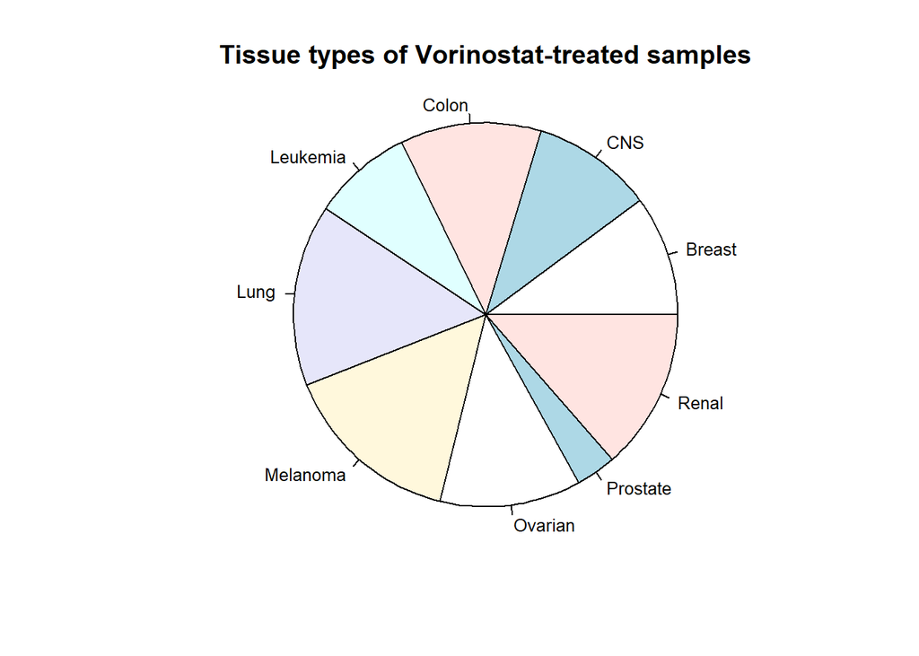

```r
Metadata <- as.matrix(Metadata)
Metadatatissue <- Metadata[1:819,"tissue"]
Treatedwithtissue <- rbind(Treated, Metadatatissue)

TreatedVorinostatcolumns <- grep(pattern = "vorinostat",colnames(Treatedwithtissue))
TreatedVorinostattissue <- Treatedwithtissue[,TreatedVorinostatcolumns]

#Create a pie chart:

palette(rainbow(9))
pie(table(TreatedVorinostattissue["Metadatatissue",]),
    main="Tissue types of Vorinostat-treated samples",
    radius=1,
    cex=0.8)
```

We see, that most of our samples belong to the tissue types “lung”, “melanoma” and “renal”. However, this does not mean that Vorinostat works best there. This is only the selection of samples for the dataset.

### 1.2.Density plot of general gene expression

This plot is done to compare the gene expression of all provided genes with and without vorinostat treatment:

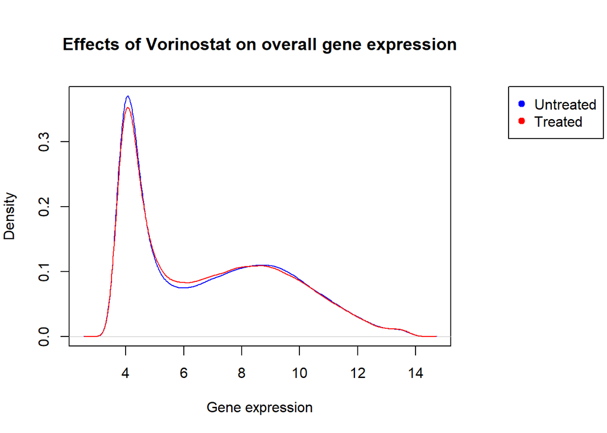

```r
TreatedVorinostat <- Treated[,TreatedVorinostatcolumns]

UntreatedVorinostatcolumns <- grep(pattern = "vorinostat",colnames(Untreated))
UntreatedVorinostat <- Untreated[,UntreatedVorinostatcolumns]

par(mar=c(5, 4, 5, 9))
plot(density(UntreatedVorinostat), col="blue",
     xlab = "Gene expression",
     main = "Effects of Vorinostat on overall gene expression")
lines(density(TreatedVorinostat), col = "red")
legend("topright", inset = c(-0.4,0), legend=c("Untreated", "Treated") , xpd = TRUE,
       pch=19, col = c("blue", "red"))
```

Altough Vorinostats working mechanism as a HDAC inhibitor should lead to a better access to genes, we do not see a higher expression in terms of all genes. We are interested in how this plot changes when we plot only our biomarkers, so we are going to repeat the density plot later when we identified them.

## 2. Create a Vorinostat-FC-matrix

For the specific analysis, it is laborious to work with the whole dataset which includes data from all 15 drugs. Consequently, we reduce the data-sets by selecting those samples that belong to vorinostat:

```r
UntreatedVorinostatcolumns <- grep(pattern = "vorinostat",colnames(Untreated))
TreatedVorinostatcolumns <- grep(pattern = "vorinostat",colnames(Treated))
```

We want to keep all genes but only the selected samples:

```r
UntreatedVorinostat <- Untreated[,UntreatedVorinostatcolumns]
TreatedVorinostat <- Treated[,TreatedVorinostatcolumns]
```

Moreover, we have to normalize the data to remove batch effects.

```r
# normalize the data
UntreatedVorinostat <- apply(UntreatedVorinostat, 2, function(x){
  (x - mean(x)) / sd(x)
})


TreatedVorinostat <- apply(TreatedVorinostat, 2, function(x){
  (x - mean(x)) / sd(x)
})

FC <- TreatedVorinostat  - UntreatedVorinostat
```

## 3. Finding biomarkers

Biomarkers are the genes which respond most to the treatment. In order to find these, we applied different methods and compared the results.

## 3.1. Biomarkers received from two-sided paired T-test (by Mert Mayadag)

In order to find the genes which show significant changes in expression levels after treatment, two-sided paired T-test was performed to calculate the p-values of gene expression changes.

Formulation of Hypotheses: **H0 hypothesis**: Gene expression does not change significantly by drug treatment. **H1 hypothesis**: Gene expression changes significantly by drug treatment.

For the application, the data frames “Treated” and “Untreated” should consist of same genes in rows and same cell lines in the sample names.

Are the genes, listed in rows, identical?

```r
identical(rownames(UntreatedVorinostat), rownames(TreatedVorinostat))
```

```
## [1] TRUE
```

However, columns have different names as these include information about drug dosis. The comparison of sample names, which include cell line information, can show us, whether the same cell lines are used and if the order is identical.

```
## [1] "786-0_vorinostat_0nM_24h" "A498_vorinostat_0nM_24h"
```

```
## [1] "786-0_vorinostat_5000nM_24h" "A498_vorinostat_5000nM_24h"
```

```
## [1] TRUE
```

Now we can apply the t-test and observe the significance of changes by investigating p-values.

```r
p_values_Vorinostat = sapply(1:13299, function(i){
                      t.test( TreatedVorinostat[i,],UntreatedVorinostat[i,],paired = TRUE,
                                                        alternative = "two.sided")$p.value
})
```

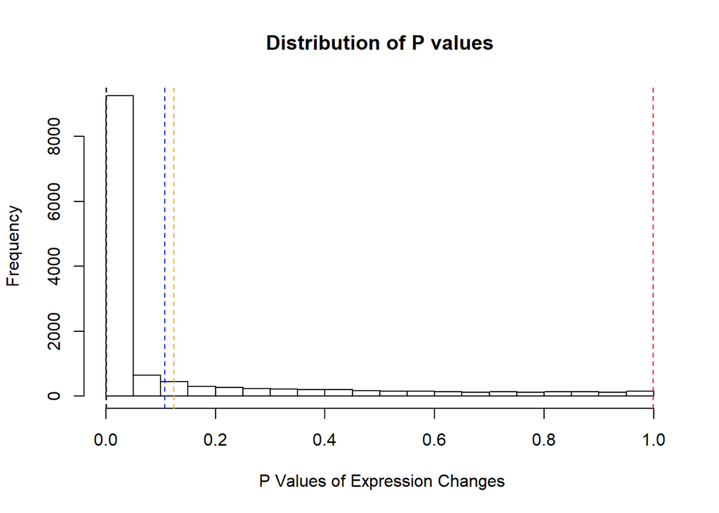

```
##              p_values significance
## MAP1LC3B 5.230833e-30         TRUE
## TOE1     1.431659e-29         TRUE
## PI4K2A   6.295537e-29         TRUE
## MEPCE    6.616561e-29         TRUE
## ATG101   8.029874e-29         TRUE
```

A lot of values are essentially zero, which would mean that many genes have showed significant responses to the treatment. This is ,however, dubious.

For now, we will select the 100 genes showing smallest p-values and compare these later with biomarkers found by other methods.

### 3.2. Biomarkers received from variance (by Mert Mayadag)

In this part, we firstly selected the genes showing high variance among the 59 cell lines.

We hypothesized that high variance of a gene could signify either - cell line specificity or - cancerogenic activity.

Then, we hypothesized that a decrease in variance would be more probable in cancerogenic genes, rather than cell line specific genes and therefore, selected the genes showing a negative variance decrease.

The steps were:

2.1 - Selecting the upper 5% of genes with highest variances 2.2 - Selecting genes which showed highest decreases in their high variance 2.3 - Depicting the drug responses(FC) of these genes with a heatmap

```r
Most_Variances_Unt              = Most_Variances_Unt[
                                 -which(Most_Variances_Unt$var < nintyfive_quartile_Untr),, drop= FALSE]
```

```r
Variance_Change                 = as.data.frame (Variances_Treated[,1] - Variances_Untreated[,1])
```

```r
Most_neg_var_change             = Variance_Change[-which(
                                  Variance_Change$Var_Change > lower_quartile_VC),, drop= FALSE]
```

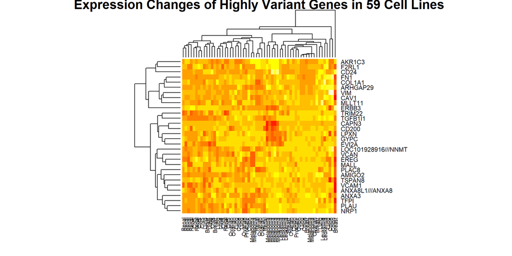

```r
heatmap(Highest_VC_Biomarkers, main = "Expression Changes of Highly Variant Genes in 59 Cell Lines")
```

## 3.3. Biomarkers received from FC values

### 3.3.1.General biomarkers

The FC value is a measure of the change in gene expression. Therefore, it is also well suited for the determination of biomarkers. In order to avoid mutually canceling effects and to find the largest change (regardless of its direction), we only use absolute values here.

```r
FC <- TreatedVorinostat - UntreatedVorinostat

FCVorinostatabs= abs(FC)
FCVorinostatmean <- apply(FCVorinostatabs, 1, mean)

#sort the values to get the 100 largest values:
sortedgeneralbiomarker <- sort(FCVorinostatmean, decreasing = TRUE)
sortedgeneralbiomarker <- as.matrix(sortedgeneralbiomarker)

#select the top 100 general biomarkers:
top100generalbiomarkers = sortedgeneralbiomarker[1:100,]
top100generalbiomarkers <- as.matrix(top100generalbiomarkers)
head(top100generalbiomarkers)
```

```
##                    [,1]
## DHRS2          1.747967
## ABAT           1.309399
## SERPINI1       1.235481
## MIR612///NEAT1 1.212957
## CLU            1.043344
## HBA2///HBA1    1.035618
```

Create a vector with gene names:

```r
generalbiomarkergenes = row.names(top100generalbiomarkers)
```

Now we have determined biomarkers via the fold change. However, since we have worked only with absolute values, we cannot say whether our genes are up- or downregulated.

### 3.3.2. Up- and Downregulation of biomarkers

We determine rowmeans of FC values. But unlike before, we do not use absolute values to calculate the averages. Consequently, we get a general overview which genes are mostly up- or downregulated.

```r
FC_meanrow= rowMeans(FC)

# look at the absolute values:
FC_meanrow = abs(FC_meanrow)

# sort the FC
sortedFC <- sort(FC_meanrow, decreasing = TRUE)
sortedFC <- as.matrix(sortedFC)

# take the first 100 values for comparison
FC100<- sortedFC[1:100,]
FC100 <- as.matrix(FC100)

# create a vector with genenames
biomarkergenes_noabs = row.names(FC100)
```

We want to compare the top biomarkers with and without using absolute values to determine how much they differ:

```r
setequal(biomarkergenes_noabs,generalbiomarkergenes)
```

```
## [1] FALSE
```

How many of the biomarkers are different?

```r
# biomarkers in biomarkergenes_noabs but not in generalbiomarkergenes
diff= setdiff(biomarkergenes_noabs,generalbiomarkergenes)
length(diff)
```

```
## [1] 5
```

```r
diff
```

```
## [1] "POLE2"   "TXNDC15" "NGFR"    "UBTF"    "GINS3"
```

We see that only 5 genes differ in the top biomarkers. Nevertheless, it is better to trust the absolute values, as they indicate the largest change in gene expression. So we avoid, that up- or down-regulating effects cancel each other out.

In order to be able to work better with the biomarkers, we creat a matrix with the information, whether the genes are up or down regulated.

```r
FCVorinostatmean_noabs= rowMeans(FC)

#Matrix with information about general up- or downregulation:
FCVorinostatmean_noabs_matrix <- as.matrix(FCVorinostatmean_noabs)

#loop, which adds those biomarkergenes to a vector, which are mostly upregulated:
i=1
Upregulated <- c()
while(i<=100) {
  if(FCVorinostatmean_noabs_matrix[generalbiomarkergenes[i],1] >0) {
    Upregulated <- union(Upregulated, generalbiomarkergenes[i])
  }
  i=i+1}

#Create a vector that includes for each gene sequentially if it is up- or downregulated:
i=1
Generalchange <- c()
while(i<=100) {
  if(FCVorinostatmean_noabs_matrix[generalbiomarkergenes[i],1] >0) {
    Generalchange <- append(Generalchange, "Up")
  } else {
    Generalchange <- append(Generalchange, "Down")
  }
  i=i+1}
```

Bind the information about up/downregulation as a new column to the biomarkermatrix:

```r
top100generalbiomarkers_withUporDown <- cbind(top100generalbiomarkers, Generalchange)
# rename
colnames(top100generalbiomarkers_withUporDown)[1] <- "FCmean"
head(top100generalbiomarkers_withUporDown)
```

```
##                FCmean             Generalchange
## DHRS2          "1.74796747187396" "Up"
## ABAT           "1.30939911773294" "Up"
## SERPINI1       "1.23548131984129" "Up"
## MIR612///NEAT1 "1.21295661353487" "Up"
## CLU            "1.043343937109"   "Up"
## HBA2///HBA1    "1.03561789420936" "Up"
```

### 3.4. Comparison of the differently received biomarkers

Now we have determined biomarkers via the 2-sided T-test and want to investigate their FC values, since our biomarkers should cause the largest change in gene expression.

Do we have exactly the same biomarkers?

```r
setequal(generalbiomarkergenes,biomarkers.genes)
```

```
## [1] FALSE
```

How many of the biomarkers are different?

```r
diff= setdiff(generalbiomarkergenes,biomarkers.genes)
length(diff)
```

```
## [1] 87
```

Obviously, the biomarkers almost do not match at all. Thus, we want to compare p.Values and FC values in a new matrix which contains both values:

```r
#sort FC matrix according biomarkers from pValues
FC=TreatedVorinostat-UntreatedVorinostat
FC_m=rowMeans(FC)
FC_m=as.data.frame(FC_m)
FC =FC_m[biomarkers.genes,]
FC=as.data.frame(FC)
```

```r
pV_FC= cbind(FC,biomarkers.pValues)
pV_FC=as.data.frame(pV_FC)
head(pV_FC)
```

```
##                  FC     p_values significance
## MAP1LC3B  0.4664444 5.230833e-30         TRUE
## TOE1     -0.5931905 1.431659e-29         TRUE
## PI4K2A    0.4831704 6.295537e-29         TRUE
## MEPCE    -0.6939825 6.616561e-29         TRUE
## ATG101    0.3859801 8.029874e-29         TRUE
## DPM1      0.2835900 1.965209e-28         TRUE
```

## 4. Visualizations of biomarkers

### 4.1. Density plot of biomarker gene expression

Now we can repeat the the **gene-expression density plot** from the beginning of our specific analysis with our biomarkers. We can see, that in terms of our identified genes Vorinostat leads to a clearly altered expression:

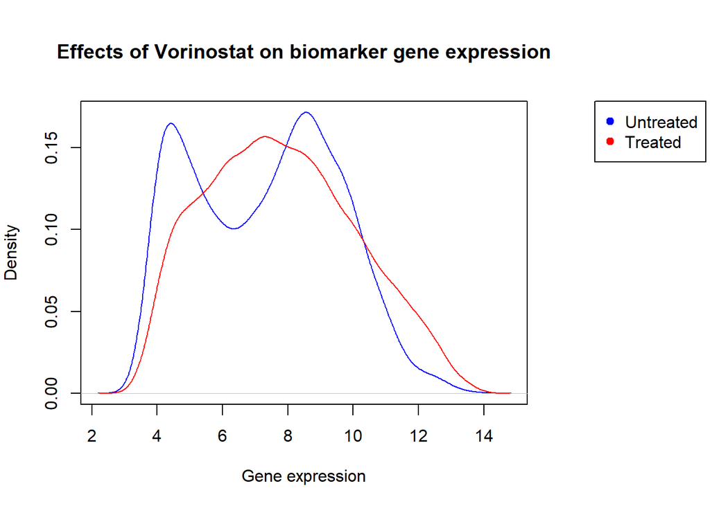

```r
Treated_Vorinostat_biomarker <- Treated[generalbiomarkergenes,TreatedVorinostatcolumns]
Untreated_Vorinostat_biomarker <- Untreated[generalbiomarkergenes,UntreatedVorinostatcolumns]

par(mar=c(5, 4, 5, 9))
plot(density(Untreated_Vorinostat_biomarker),col="blue" ,xlab = "Gene expression",
     main = "Effects of Vorinostat on biomarker gene expression")

lines(density(Treated_Vorinostat_biomarker), col = "red")

legend("topright", inset = c(-0.4,0), legend=c("Untreated", "Treated") , xpd = TRUE,
       pch=19, col = c("blue", "red"))
```

### 4.2. Barplots of up- and downregulation of biomarkers

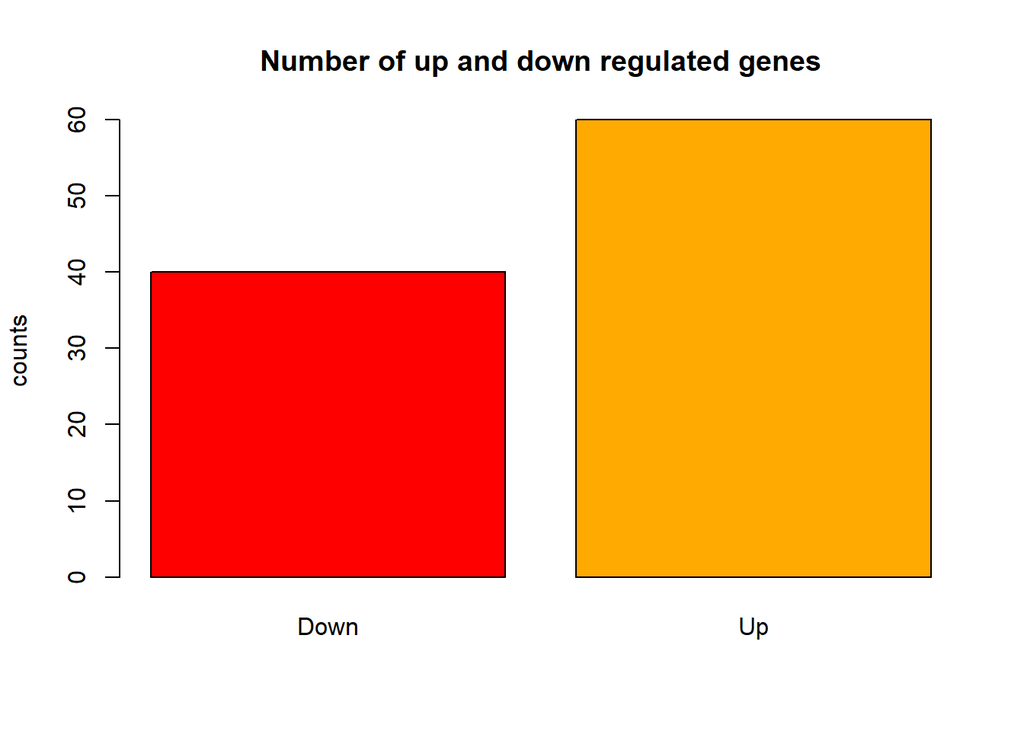

```r
top100generalbiomarkers_withUporDown=as.data.frame(top100generalbiomarkers_withUporDown)
change=top100generalbiomarkers_withUporDown$Generalchange
col=palette(rainbow(2))
barplot(table(change), ylab="counts", main="Number of up and down regulated genes", col=col)
```

Another option to visualize the up- and downregulation of the biomarkers:

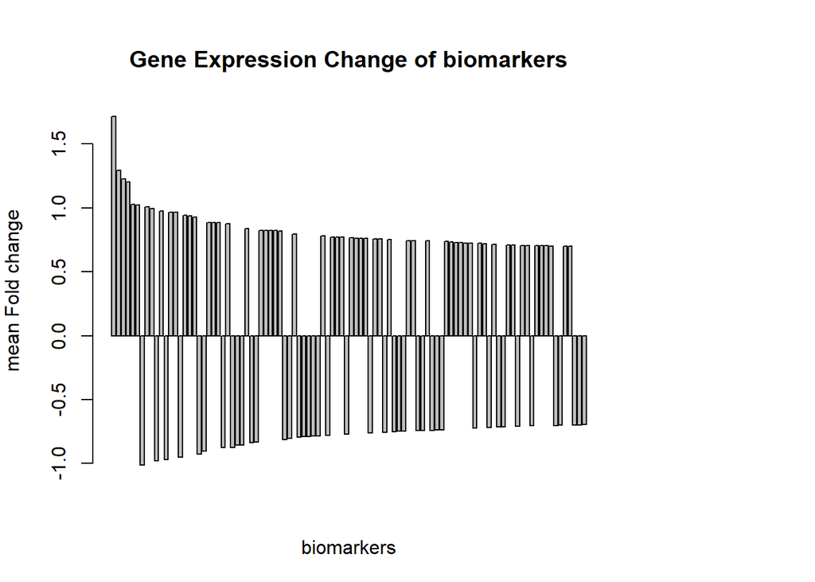

```r
FC=TreatedVorinostat-UntreatedVorinostat
FC_meanrow= rowMeans(FC)
FC_abs= abs(FC_meanrow)

FC_both= cbind(FC_meanrow,FC_abs)
FC_both=as.data.frame(FC_both)

# order this matrix
FC_both_sorted <- FC_both[order(FC_both$FC_abs, decreasing = TRUE),]

# FC values of biomarkers
# take the first 100 of the sorted matrix, should be the same as un biomarkers_FC
biomarkers_FC_values = FC_both_sorted[1:100,]
# remove the absolute values
biomarkers_FC_values <- subset( biomarkers_FC_values, select = -FC_abs)
biomarkers_FC_values = as.data.frame(biomarkers_FC_values)

par(mar=c(5, 4, 5, 9))
barplot( height= biomarkers_FC_values$FC_meanrow,
         main= "Gene Expression Change of biomarkers",
         ylab="mean Fold change", xlab="biomarkers")
```

We see that most values are very similar to each other.

### 4.3. Visualization of biomarkers with Vulcanoplot

First we perform a one-sample t.test with normalized FC data:

```r
T.testFC <- apply(FC, 1, t.test)
```

Save the results in a data frame:

```r
TResults <- lapply(T.testFC, function(.tres) {

  data.frame(t.value=.tres[1],dfs=.tres[2],conf.int1=.tres$conf.int[1],conf.int2=
               .tres$conf.int[2],p.value=.tres[3])
})

Tfinalresults <- do.call(rbind, TResults)
```

For the vulcano plot, a package needs to be installed: if (!requireNamespace(‘BiocManager’, quietly = TRUE)) install.packages(‘BiocManager’) BiocManager::install(‘EnhancedVolcano’)

```r
library(EnhancedVolcano)
```

Since we are interested in general biomarkers, we use the mean FC of the columns:

```r
log2FC <- apply(FC, 1, mean)
```

Add the FCvalues as a new column to the data frame containing the results of the t.test:

```r
FCandpvalues <- cbind(Tfinalresults, log2FC)
```

Create a Vulcanoplot:

First, all genes are assigned to the color black. Subsequently, those genes with a FC equal or larger than the smallest FC of the top 100 FC-values are colored in gold. Those, which exceed the same limit in the negative range are assigned to the color green.

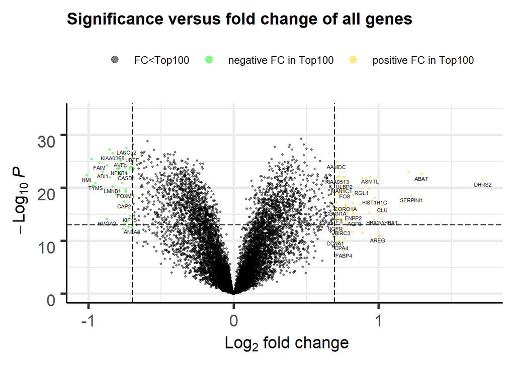

```r
keyvals <- rep('black', nrow(FCandpvalues))
names(keyvals) <- rep('FC<Top100', nrow(FCandpvalues))

keyvals[which(FCandpvalues$log2FC >= min(FC100))] <- 'gold'
names(keyvals)[which(FCandpvalues$log2FC >= min(FC100))] <- 'positive FC in Top100'

keyvals[which(FCandpvalues$log2FC <= -min(FC100))] <- 'green'
names(keyvals)[which(FCandpvalues$log2FC <= -min(FC100))] <- 'negative FC in Top100'

EnhancedVolcano(FCandpvalues,
                lab = rownames(FCandpvalues),
                x = 'log2FC',
                y = 'p.value',
                title = 'Significance versus fold change of all genes',
                selectLab = biomarkergenes_noabs,
                transcriptLabSize = 1.8,
                colOverride = keyvals,
                pCutoff = 10e-14,
                FCcutoff = min(FC100)
              )
```

Now we want to further investigate our biomarkers.

## 5. Are the targets for vorinostat (HDACs) part of our biomarkers?

As already mentioned in the introduction, metadata describes the HDACs as targets of Vorinostat. Now we want to investigate whether these are among our biomarkers. To do this, we first create a vector that contains the target names.

```r
###find target of vorinostat

target=Drug_annotation$target
target=as.data.frame(target)

# take row with vorinostat
target_vorinostat=target[9,]
target_vorinostat
```

```
## [1] HDAC1|HDAC10|HDAC11|HDAC2|HDAC3|HDAC5|HDAC6|HDAC8|HDAC9
## 15 Levels: ABL1|ABL2|BLK|EPHA2|FGR|FRK|FYN|HCK|KIT|LCK|LYN|PDGFRB|SRC|SRMS|STAT5B|YES1 ...
```

We create a vector with targetnames as strings, because otherwise we have a problem with spacer |.

```r
target_vorinostat=c("HDAC1","HDAC10","HDAC11","HDAC2","HDAC3","HDAC5","HDAC6",
                    "HDAC8","HDAC9")
```

Do we have HDACs in our biomarkers?

```r
# search for HDAC in biomarkers
target <- grep(pattern = "HDAC",colnames(top100generalbiomarkers))
length(target)
```

```
## [1] 0
```

In drug annotation, HDAC genes are mentioned as target of vorinostat, but these genes are not in our defined biomarkers, so we want to check their FC values:

```r
### find FC values of targets

# create FC data
FC_meanrow = as.data.frame(FC_meanrow)
genes = row.names(FC_meanrow)
FC_new=cbind(FC_meanrow,genes)


# filter data
FC_target = as.data.frame(filter(FC_new, genes %in% target_vorinostat))

knitr::kable(head(FC_target), caption = "FC values vorinostat targets")
```

FC values vorinostat targets

| FC_meanrow | genes |
| --- | --- |
| 0.1248735 | HDAC1 |
| 0.0247844 | HDAC11 |
| -0.0119615 | HDAC2 |
| 0.4081318 | HDAC3 |
| 0.4662200 | HDAC5 |
| 0.1102505 | HDAC6 |

The changes in gene expression are really small. Most of the HDAC genes are slightly upregulated. The cells might want to compensate the inhibition of the enzymes by their increased formation.

**Create a boxplot of HDACs in comparison to biomarkers**

To compare the FC of the HDAC genes with some of our biomarkers, we create a vector which contains both biomarkers and HDAC-genes.

```r
first10biomarkers= generalbiomarkergenes[1:10]
c=union(target_vorinostat,first10biomarkers)
```

Find the FC values of those genes in the vector in the FC matrix:

```r
FC= TreatedVorinostat-UntreatedVorinostat
FC=as.data.frame(FC)

FC_HDAC <-FC[c,]
```

Not all HDAC targets which were listed in the annotation data can be found in our expression data, so we remove the missing ones:

```r
FC_HDAC =na.omit(FC_HDAC)
```

Now we plot a boxplot in order to visualize the much lower effect on HDAC-gene-expression compared to some of our biomarkers:

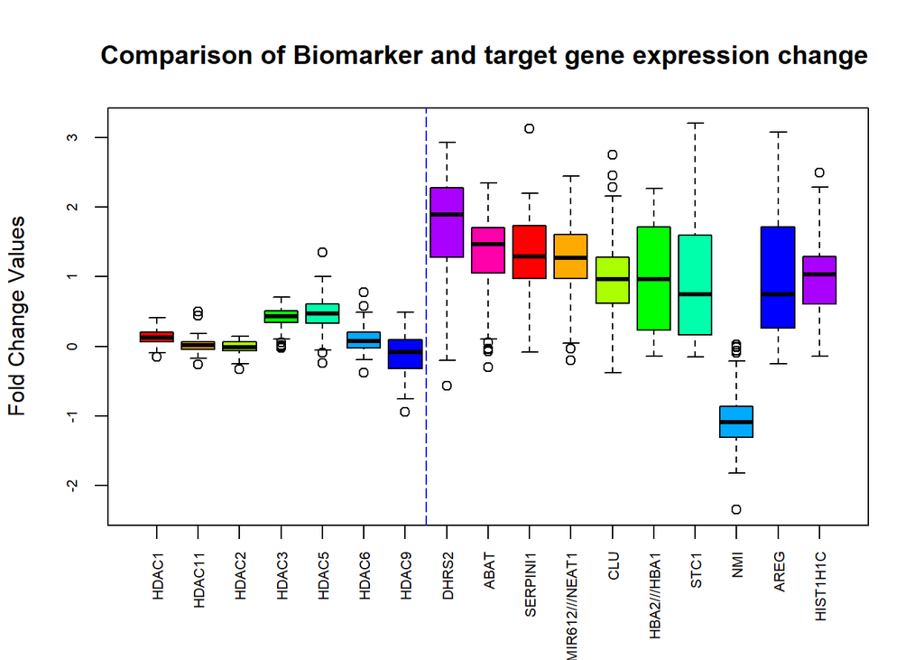

```r
palette(rainbow(17))
boxplot(t(FC_HDAC), las=3, col = col, ylab="Fold Change Values", cex.axis= 0.65,  main="Comparison of Biomarker and target gene expression change ")
abline(v=7.5, col="blue", lty=5)
```

## 6. Find biomarkers only for leukemia-celllines

Since we found in the beginning, that Vorinostat is used against T-cell lymphomas, we are interested in how Vorinostat influences especially the leukemia-celllines. Therefore, we now want to investigate the most affected genes in those specific samples.

We thought about possible reasons, why vorinostat works better for certain cancer types like T-cell lymphomas compared to other cancer types. Altought each sample contains a lot of different HDACs, which regulate the chromatin structure of different areas or rather of different histone types, the composition of HDACs probably differs in different samples. It might be, that vorinostat has the greatest inhibition effect on those HDAC types present in T-cell lymphomas. The areas regulated by the affected HDACs might contribute most to the harmful effect on tumor cells.

The general biomarkers we found before are representative for all samples but we do not know whether the genes showing a significantly altered expression after treatment do really contribute to vorinostats anticancer-effect. It is important to remember, that some genes might only be up- or downregulated as a side effect if adjacent genes are exposed or the chromatin of adjacent areas is compacted. Now we identify the genes with the highest expression changes only in leukemia celllines since we expect that those genes may contribute more to Vorinostats anticancer effect. We compare our biomarkers representative for all samples with the biomarkers received from leukemia samples. The overlap might identify those genes which were significantly altered expressed in a lot of different samples and additionally probably contribute to vorinostats anticancer effect since their expressions distinctly changed in those samples the treatment was most successful.

```r
#We only need the tissueinformation of those samples treated with Vorinostat
#Since Metadata includes them twice, once with and once without drug treatment,
#we select only the Treated samplenames:
Vorinostatsamples <- grep(Metadata$sample, pattern= "vorinostat_5000nM")
Metadatavorinostattissue <- Metadata[Vorinostatsamples,"tissue"]

#Add the tissueinformation as a new row to the FCVorinostat-matrix:
FCwithtissue <- rbind(FC, Metadatavorinostattissue)

#select only those samples/celllines which belong to Leukemia:
FCwithtissue <- as.data.frame(FCwithtissue)
Leukemiasamples <- colnames(FCwithtissue[Metadatavorinostattissue== "Leukemia"])
FCLeukemia <- FCwithtissue[,Leukemiasamples]

#Now we do not need the tissue information any longer:
FCLeukemia <- FCLeukemia[-13300,]

#We want the FC-mean for each gene:
FCLeukemiaabs <- abs(FCLeukemia)
FCLeukemiameans <- apply(FCLeukemiaabs,1 ,mean)

#Sort the biomarkers that those with the biggest FC are on top:
sortedFCleukemiamean <- sort(FCLeukemiameans, decreasing = TRUE)
sortedFCleukemiamean <- as.matrix(sortedFCleukemiamean)

# take the first 100 as Leukemia-biomarkers:
biomarkersLeukemia = sortedFCleukemiamean[1:100,]
biomarkersLeukemia <- as.matrix(biomarkersLeukemia)

# create a vector with gene names of Leukemia-biomarkers:
biomarkersLeukemiaGenes = row.names(biomarkersLeukemia)


#Comparison with general biomarkers:
intersect(biomarkersLeukemiaGenes, generalbiomarkergenes)
```

```
##  [1] "DHRS2"                 "MIR612///NEAT1"
##  [3] "ID2B///ID2"            "PSMB10"
##  [5] "HIST1H2BJ///HIST1H2BG" "SERPINI1"
##  [7] "ADI1"                  "CRISPLD2"
##  [9] "TUFT1"                 "CDKN1A"
## [11] "NMI"                   "PEG10"
## [13] "NEU1"                  "AKR1C3"
## [15] "TNFSF9"                "UTP20"
## [17] "FKBP1B"                "RCN1"
## [19] "SYT11"                 "NRGN"
## [21] "HIST1H2AE"             "ASMTL"
## [23] "NSMAF"                 "MAN1C1"
## [25] "ZMYND11"               "ENPP2"
## [27] "LANCL2"                "ABAT"
## [29] "RGL1"                  "PMF1"
## [31] "PHF2"                  "TMEM35B///ZMYM6"
## [33] "KIAA0368"              "CLU"
## [35] "MPDU1"                 "BID"
## [37] "JADE2"                 "TUBB4A"
## [39] "TUBB2B"                "FOS"
```

```r
biomarkersLeukemiaGenes[biomarkersLeukemiaGenes == generalbiomarkergenes]
```

```
## [1] "DHRS2"
```

We found, that 40 % of our general biomarkers show a great change in leukemia-samples as well. We still can not assume, that those are the genes involved in cancer development but we can say that they are reliably changed in different samples and that at least some of them play a role in cancer progress.

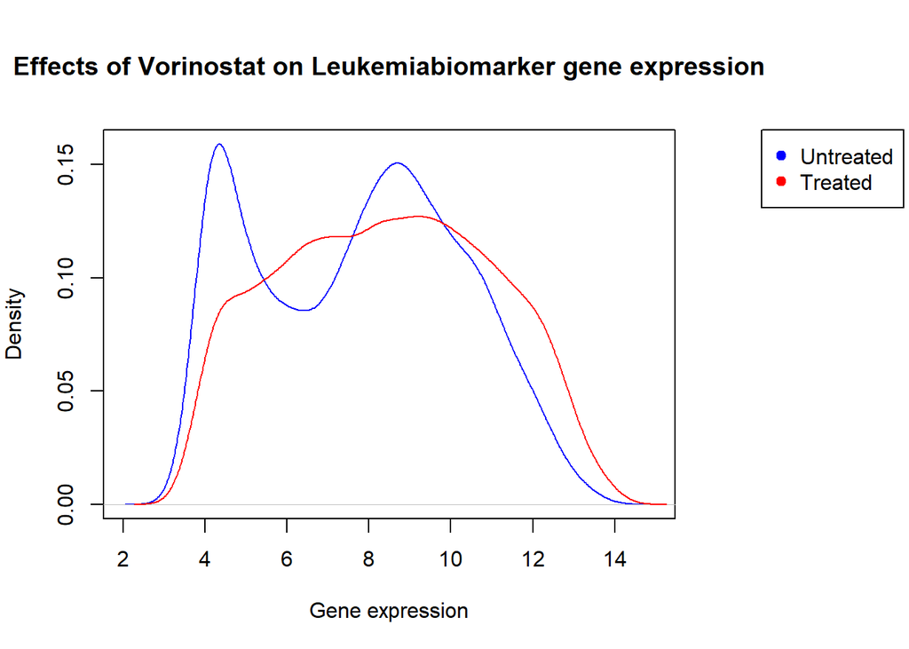

```r
Treated_Leukemiabiomarker <- Treated[biomarkersLeukemiaGenes ,TreatedVorinostatcolumns]
Untreated_Leukemiabiomarker <- Untreated[biomarkersLeukemiaGenes,UntreatedVorinostatcolumns]

par(mar=c(5, 4, 5, 9))
plot(density(Untreated_Leukemiabiomarker) ,xlab = "Gene expression", col = "blue",
     main = "Effects of Vorinostat on Leukemiabiomarker gene expression")
lines(density(Treated_Leukemiabiomarker), col = "red")
legend("topright", inset = c(-0.4,0), legend=c("Untreated", "Treated") , xpd = TRUE,
       pch=19, col = c("blue", "red"))
```

The plot looks quite similar to the plot before which contained the general biomarkers. Since the biomarkers of leukemia are partly the same as the general biomarkers, the similarity of the plots is not surprising.